# Mediation, Moderation & Conditional Process Analysis

## Simple Moderation — Model 1

PTSS × Sexual minority status → Delinquency

What Is Moderation? The Two Diagrams

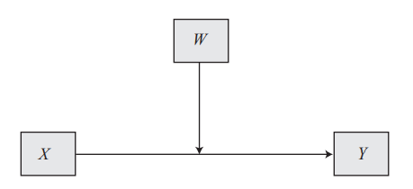

Conceptual: W modifies the X→Y relationship

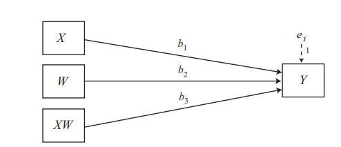

Statistical: XW interaction term is the test

📖 READING THE DIAGRAMS

**Conceptual:** W 'sits on' the X→Y arrow — modifies its strength or direction.

**Statistical:** We add XW (X × W, mean-centred) to regression. b₃ on XW IS the formal test.

Ŷ = i + b₁(X) + b₂(W) + b₃(X×W)

If **b₃ is significant → MODERATION CONFIRMED**.

🌍 MODERATION vs MEDIATION

**Mediation:** HOW does X affect Y? (mechanism)  
**Moderation:** FOR WHOM or WHEN does X affect Y? (condition)

🔑 THE ONLY TEST

The ONLY test of moderation is the significance of **b₃ (the interaction term)**. A non-significant main effect of W (b₂) does NOT mean W is not a moderator.

Example 7 — Study Context, Variables & PROCESS Setup

🔬 STUDY CONTEXT

Data from youth in the child welfare system. We know PTSS predicts delinquency — but equally for ALL youth?

Sexual minority (LGBTQ+) youth face unique stressors NOT experienced by heterosexual youth: discrimination, family rejection, victimisation by peers, and less access to affirming support. These may **amplify** how trauma translates into delinquent behaviour.

❓ HYPOTHESIS

b₃ (ptss × sexmin) will be **positive and significant** — trauma more strongly linked to delinquency for LGBTQ+ youth.

| **X** | ptss | Post-traumatic stress symptoms |
| --- | --- | --- |
| **W** | sexmin | 1=LGBTQ+, 0=heterosexual |
| **Y** | delinq | Delinquent behaviour score |

[figure not shown]

PROCESS setup: Model 1, Y=delinq, X=ptss, W=sexmin

Moderation — PROCESS Options Setup

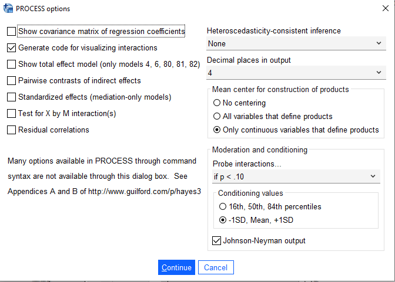

Key options: visualisation code + J-N output + mean centring

📖 KEY OPTIONS TO ENABLE

🔑 WHEN TO USE J-N

With a continuous moderator (like age), J-N gives the exact threshold — far more informative than just 3 percentile values. See Part 7.

Moderation Results — Output & Equations

| constant | 1.7075 | .263 | <.001 | — |
| --- | --- | --- | --- | --- |
| ptss (main) | −0.0450 | .062 | .467 | ❌ |
| sexmin (main) | 1.7454 | .529 | .001 | ✅ |
| **ptss × sexmin (Int_1)** | **0.2579** | .125 | **.040** | **✅ MODERATION!** |

R²=.141, F=6.60, p=.0004

📖 THE TWO EQUATIONS

**Heterosexual (W=0):**  
Ŷ = 1.71 + (−0.045)(ptss) — flat, not sig

**LGBTQ+ (W=1):**  
Ŷ = 3.455 + (0.213)(ptss) — positive, rising

b₃ = 0.258 IS the difference in slopes between the two groups.

🌍 REAL-LIFE MEANING

**Moderation confirmed (b₃=0.2579, p=.040).**

**Heterosexual youth:** PTSS does NOT significantly predict delinquency.

**LGBTQ+ youth:** Higher PTSS → more delinquency. Trauma uniquely externalises as delinquent behaviour for sexual minority youth.

**Policy implication:** Trauma-informed delinquency prevention must SPECIFICALLY target sexual minority youth. Universal programmes may be insufficient.

Model WITHOUT Interaction — Parallel Slopes: Dummy Variable Shifts Intercept Up

[interactive chart not shown]

Ŷ = 1.71 − 0.045(ptss) + **1.745(sexmin)** — No interaction term

📖 WHAT THIS SHOWS

Without an interaction term, the two lines are **perfectly parallel** — identical slopes, shifted vertically. The dummy variable b₂ = **+1.745** lifts the sexual minority line up by 1.745 units at EVERY value of PTSS.

📐 THE TWO EQUATIONS

**Heterosexual (sexmin=0):**  
Ŷ = 1.71 + (−0.045)(ptss)

**Sexual minority (sexmin=1):**  
Ŷ = 1.71 + 1.745 + (−0.045)(ptss) = **3.455** + (−0.045)(ptss)

🔑 KEY POINT

Parallel slopes = **effect of PTSS on delinquency is IDENTICAL** for both groups. Only baseline differs. This is the null hypothesis — no moderation.

Model WITH Interaction — Diverging Slopes: PTSS Has a Stronger Effect for Sexual Minority Youth

[interactive chart not shown]

Ŷ = 1.71 − 0.045(ptss) + 1.745(sexmin) + **0.258(ptss×sexmin)**

📖 WHAT THIS SHOWS

Adding b₃ = **+0.258** changes the **slope** for sexual minority youth. Lines **DIVERGE** — gap widens as PTSS increases.

📐 THE SLOPE CHANGE

**Heterosexual slope:** −0.045 (flat)  
**Sexual minority slope:**  
−0.045 + 0.258 = **+0.213** (rising)

b₃ = 0.258 IS the difference in slopes (p=.040 ✅)

🌍 REAL-LIFE MEANING

**Heterosexual youth:** more trauma → slightly less delinquency (not significant).  
**LGBTQ+ youth:** more trauma → significantly more delinquency. Trauma externalises for this group.

Side-by-Side Comparison — No Interaction vs With Interaction

[interactive chart not shown]

❌ NO INTERACTION

Both slopes = **−0.045**. Dummy shifts intercept **UP by +1.745**. Lines perfectly **parallel**.

[interactive chart not shown]

✅ WITH INTERACTION (b₃=0.258, p=.040)

Hetero slope = −0.045 | Sexmin slope = **+0.213**. Lines **diverge** → MODERATION.

🎯 CHECK YOUR UNDERSTANDINGSimple Moderation — Identifying the Test

Output: b1(stress)=0.45, p=.001; b2(gender)=0.12, p=.34; b3(stress×gender)=0.31, p=.08. What is concluded?

A. Moderation confirmed — b₃ is close to significance

B. Moderation NOT confirmed — b₃ (p=.08) is not significant at .05

C. Gender not a moderator because b₂ is non-significant

D. Stress is the only significant predictor

Click an option to check your answer

🎯 CHECK YOUR UNDERSTANDINGModeration — Real-Life Interpretation

Homework (X) → grades (Y): b=0.8 for high-motivation (W=1), b=0.1 for low-motivation (W=0). Interaction significant. What does this mean?

A. Motivation causes homework — it's a mediator

B. The effect of homework on grades DEPENDS ON motivation level

C. Homework has zero effect on low-motivation students

D. Motivation should be removed as a confounder

Click an option to check your answer

Part 7

## Johnson-Neyman Technique

Finding the exact value of W where the effect becomes statistically significant

Age as Continuous Moderator — PROCESS Setup & Options

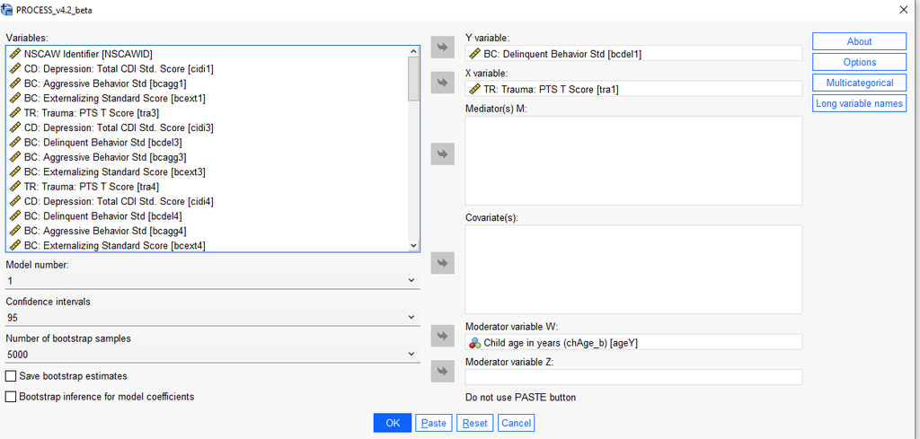

Model 1: Y=bcdel1, X=tra1, W=ageY | N=1,910

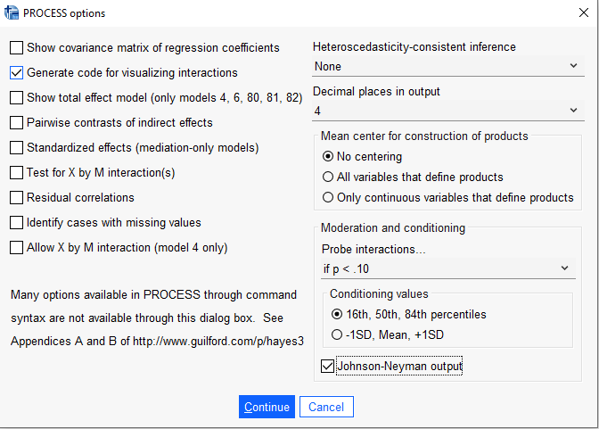

Key options: J-N output ✓ | Generate code ✓ | Percentiles

📖 WHY J-N?

With a **continuous moderator** (age), J-N gives the **exact value of W** where the conditional effect crosses p=.05. Far more informative than just 3 percentile snapshots.

J-N Full PROCESS Output — Complete Output

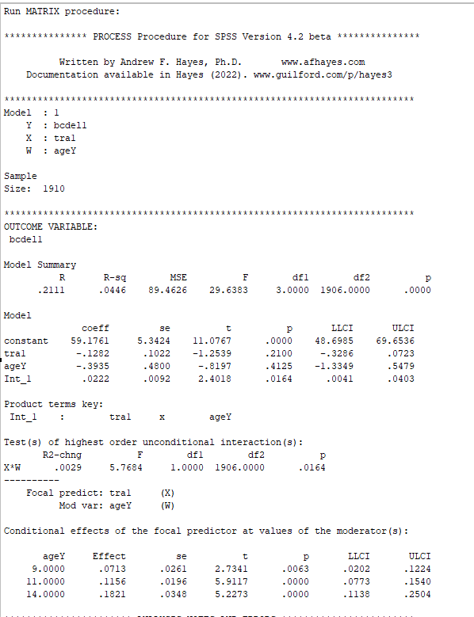

Full PROCESS output: Model 1, Y=bcdel1, X=tra1, W=ageY | Interaction confirmed Int_1=0.0222, p=.016 | Conditional effects at ages 9, 11, 14

J-N Full PROCESS Output — Reading the Results

📖 INTERACTION: Int_1=0.0222, p=.016 ✅

PTSS × age interaction is statistically significant! R²-change=.003, F=5.768, p=.016. Moderation is confirmed — age changes the PTSS→delinquency relationship.

📖 CONDITIONAL EFFECTS AT THREE AGES

| Age (percentile) | Effect of PTSS | p | Sig? |
| --- | --- | --- | --- |
| 9 (16th) | 0.0713 | .006 | ✅ |
| 11 (50th) | 0.1156 | <.001 | ✅ |
| 14 (84th) | 0.1821 | <.001 | ✅ |

🌍 WHAT THE PERCENTILES SHOW

The effect of PTSS on delinquency GROWS with age:

β=0.071 at age 9 → β=0.116 at age 11 → β=0.182 at age 14

⚠️ WHERE DOES IT BECOME SIGNIFICANT?

The percentile values show the effect is significant at ages 9, 11, and 14. But what about children aged 8? 7?

The J-N technique (next slide) gives us the exact threshold.

Johnson-Neyman Significance Region

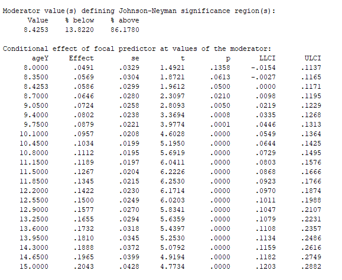

J-N threshold: age 8.43 — 86% of sample above this

📖 LINE-BY-LINE READING

**Threshold=8.4253:** PTSS effect becomes significant at age 8.43.

**13.82% below:** 13.8% of children young enough that effect is NOT significant.

**86.18% above:** large majority — PTSS significantly predicts delinquency.

**Age 8.0:** CI includes 0 → not sig.  
**Age 8.43:** exactly p=.05.  
**Age 9.5+:** all CIs exclude 0.

🌍 REAL-LIFE MEANING

PTSS starts predicting delinquency at ~age 8.5. For younger children, trauma may manifest as internalising (anxiety, depression). For older children it externalises as delinquency.

**Screen for PTSS-delinquency links especially in children aged 9+.**

Moderation Plot — Age × PTSS → Delinquency

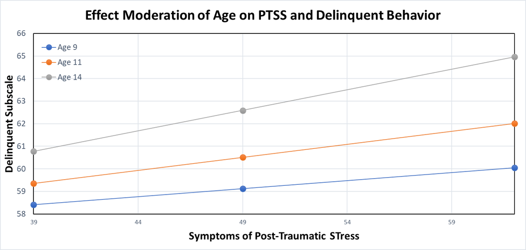

Diverging lines confirm moderation visually

📖 HOW TO READ THIS GRAPH

- **All lines slope UP:** higher PTSS = more delinquency for all ages
- **Lines DIVERGE (not parallel):** this IS moderation
- **Age 14 (gray):** highest baseline AND steepest slope
- **Age 9 (blue):** lowest baseline AND flattest slope

Parallel lines → NO moderation  
Diverging lines → MODERATION ✅

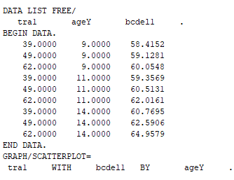

PROCESS outputs this syntax automatically

🎯 CHECK YOUR UNDERSTANDINGJohnson-Neyman Technique

J-N output: threshold = 8.43 years, 86.18% of sample above. What does this mean?

A. Only 13.82% show a significant moderation effect

B. PTSS→delinquency effect is significant for children aged 8.43 and above (86.18%)

C. Children must be ≥8.43 to be included in PROCESS

D. The model explains 86.18% of variance

Click an option to check your answer

Part 8

## Practice Problems in R

cardiomoon.shinyapps.io/processR | Data: ptx_vex_mod_mediation.sav

Three Practice Exercises

EXERCISE 1: Parallel Mediation (Model 4)

Test whether **depression at Time 3 OR Time 4** independently mediates PTSS (T1) → delinquency (T4). Enter T3 and T4 depression as two separate parallel mediators. Look for specific indirect effects via bootstrapped CIs and use contrasts to compare them.

EXERCISE 2: Serial Mediation (Model 6)

Test whether **depression at T3 THEN T4** serially mediates PTSS → delinquency. Hypothesis: T3 depression CAUSES T4 depression. Enter T3 first, T4 second. Look for Ind3 = PTSS → dep_T3 → dep_T4 → delinquency.

EXERCISE 3: Moderation (Model 1)

Test whether **age moderates** PTSS → delinquency. X=PTSS, W=Age, Y=Delinquency. Enable J-N output. Create the interaction plot — parallel or diverging lines? At what age does the effect become significant?

🎯 CHECK YOUR UNDERSTANDINGBig Picture — Which Analysis?

Theory: trauma (X) → anxiety (M1) → poor sleep (M2) → poor health (Y). Anxiety causes poor sleep. Which analysis?

A. Parallel mediation

B. Serial mediation — M1 causes M2

C. Simple mediation

D. Moderation

Click an option to check your answer

🎯 CHECK YOUR UNDERSTANDINGBig Picture — Mediation vs Moderation

SES (X) → mental health (Y): relationship stronger for immigrants than non-immigrants. Mediation or moderation?

A. Mediation

B. Moderation — immigration changes the STRENGTH of the SES→mental health relationship

C. Both

D. Need more information

Click an option to check your answer

Quick Reference — Golden Rules & Model Selection

| Does W change the X→Y effect? | **Model 1** | Tests XW interaction (b₃). Use J-N for continuous W. |
| --- | --- | --- |
| X→Y through one M | **Model 4** | a, b, c′, indirect via bootstrapped CI |
| X→Y through multiple independent M's | **Model 4** | Specific indirect effects. Contrasts. c=c′+Σaibi. |
| Mediators cause each other | **Model 6** | d₂₁ path; Ind3=a₁×d₂₁×b₂; order matters! |
| Parallel + serial combined | **Model 81** | Check Hayes book appendix |

🔑 FOUR GOLDEN RULES

**Rule 1:** c = c′ + ab always. Total = direct + all indirect effects.

**Rule 2:** Indirect effects → bootstrapped CIs only. CI excludes 0 ✅ / CI includes 0 ❌.

**Rule 3:** Moderation = non-parallel lines. b₃ on XW is the statistical test.

**Rule 4:** Serial → order of M's defines your causal hypothesis. Theory drives the model.